# ELE618 - Sistemas Elétricos Industriais

Instalações Elétricas - Ademaro A. M. B. Cotrim  
Cap7 - Ademaro A. M. B. Cotrim

Prof. Dr. Thales A. C. Maia

UFMG - DEE

# Introdução

## Princípio Fundamental e Tipos de Proteção

- Princípio fundamental (NBR 5410:2004): as partes vivas perigosas não devem ser acessíveis e as massas não devem oferecer perigo
- Proteção básica (contra contatos diretos): isolação, barreiras, invólucros, obstáculos, DR, limitação de tensão
- Proteção supletiva (contra contatos indiretos): eqüipotencialização, seccionamento automático, isolação suplementar, separação elétrica

# Limitação da Tensão de Alimentação

## Extrabaixa Tensão de Segurança

- SELV (Separated Extra-Low Voltage): circuito separado da terra e de outros sistemas, sem pontos aterrados
- PELV (Protected Extra-Low Voltage): equivalente ao SELV, mas permite aterramento
- Tensão limitada a valores que não superem a tensão de contato-limite (UL)

## Proteção em SELV e PELV

- Limites de tensão: máximo de 50 V em CA ou 120 V em CC
- Pode dispensar proteção básica (isolação) se a tensão não for superior a 25 V (CA) ou 60 V (CC), dependendo do ambiente
- Proteção supletiva garantida por separação entre o sistema SELV/PELV e outros circuitos (isolação dupla, blindagem)

## Fontes para SELV e PELV

- Transformador de separação de segurança (TSS)
- Fonte de corrente com grau de separação equivalente (grupo motor-gerador)
- Fontes autônomas (pilhas ou baterias)
- Fonte eletrônica projetada com limite de tensão segura na saída

# Extrabaixa Tensão Funcional

## Sistema FELV

- FELV (Functional Extra-Low Voltage): usada por razões funcionais, não preenche os requisitos do SELV e PELV
- Aplica-se a circuitos com pontos aterrados ou alimentados por fontes sem separação de segurança plena
- Não constitui proteção por si só, devendo ser complementada por outras medidas contra contatos diretos e indiretos

# Equipamentos Classe II e Isolação Equivalente

## Isolação Equivalente

- Equipamentos classe II oferecem proteção intrínseca sem necessidade de aterramento (dupla isolação ou isolação reforçada)
- “Isolação equivalente”: isolação suplementar envolvendo componentes elétricos com isolação básica, equiparando-se à classe II
- Exemplos: condutores em eletrodutos isolantes ou dispositivos em caixas isolantes

# Locais Não Condutores e Eqüipotencialização

## Proteção em Locais Não Condutores

- Locais com piso e paredes de alta resistência (ex: > 50 kΩ até 500 V)
- Evita que pessoas toquem simultaneamente partes com potenciais distintos, por afastamento (≥ 2 m) ou uso de obstáculos
- Restrito a situações supervisionadas e controladas

## Ligações Eqüipotenciais Locais Não Aterradas

- Todas as massas e elementos condutores interligados, porém sem aterramento
- Garante que a diferença de potencial entre partes tocáveis seja praticamente nula
- A NBR 5410 recomenda que devem ser tomadas precauções para garantir o acesso de pessoas ao local considerado, sem que elas possam ser submetidas a uma diferença de potencial perigosa. Isso se aplica, principalmente, ao caso em que um piso condutor isolado do solo é ligado à ligação eqüipotencial.

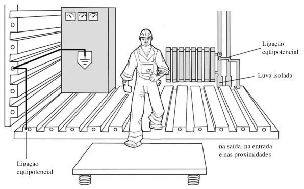

Fig. 1: Ligação eqüipotencial local não aterrada (Cotrim, 2009)

# Proteção por Separação Elétrica

## Separação Elétrica

- Alimentação por fonte de separação (ex: transformador específico) para inviabilizar caminho da corrente pela terra
- Limitações: comprimento do circuito restrito a 500 m e Produto V×m ≤ 100.000
- Massas interligadas sem ligação intencional à terra

# Exercícios

## 1 a 4

- O que compreende o princípio fundamental relativo à proteção contra choques elétricos? . . . Que partes vivas perigosas não devem ser acessíveis e massas ou partes condutoras não devem oferecer perigo, em condições normais ou sob falha.
- Explique o que são as proteções básica e supletiva? . . . Básica protege contra contatos diretos (ex: isolação). Supletiva atua contra contatos indiretos (ex: eqüipotencialização e seccionamento).
- Defina o que é um sistema SELV. . . . Sistema de extrabaixa tensão de segurança, eletricamente separado da terra e de outros circuitos.
- Defina o que é um sistema PELV. . . . Sistema de extrabaixa tensão de segurança que atende aos requisitos do SELV, mas permite o aterramento.

## 5 a 7

- Quais são as possíveis fontes que proporcionam uma completa separação galvânica? . . . Transformador de separação (TSS), fontes equivalentes, autônomas (baterias) ou eletrônicas específicas.
- O que é o termo extrabaixa tensão funcional, denominada FELV? . . . Sistema de extrabaixa tensão usado por funções técnicas que não cumpre requisitos de segurança totais do SELV/PELV, exigindo proteção extra.
- Quais são as prescrições quanto à construção para equivalente da classe II? . . . Uso de isolação suplementar ao redor de partes com isolação básica, resistindo às influências externas e mantendo propriedades.

## 8 a 10

- Quais as características dos locais considerados não condutores? . . . Paredes e pisos com resistência mínima de 50 kΩ (até 500 V) ou 100 kΩ (acima de 500 V).
- No que consiste a proteção por separação elétrica? . . . Alimentação de circuitos por fontes de separação galvânica, não permitindo retorno de corrente pela terra durante faltas.
- O que a NBR 5410 recomenda para evitar riscos de faltas para terra em cabos flexíveis? . . . Atenção à isolação e resistência mecânica (condições AG2); os cabos flexíveis devem ser visíveis e poderem suportar esforços.

# Obrigado!

http://thalesmaia.com/